# Digihumanitaaria ja tekstianalüüs

Maarja-Liisa Pilvik

Tartu Ülikool, eesti ja üldkeeleteaduse instituut

23.03.2021

# Tänane kava

- 13.25-14.35
  - Väike keeleteaduslik katse
  - Mis on digihumanitaaria?
  - Tekstianalüüs. Lähi- ja kauglugemine. Mis on sõnad? Kuidas neid kokku lugeda?
  - “Eesti Laul 2021” laulusõnade analüüs tööriistaga VoyantTools
- 14.45-15.55
  - Keelevarieerumine. Kuidas me valime “võrdsete” väljendite vahel?
  - Katsetulemuste analüüs

# Väike keeleteaduslik katse

Vasta [sellel lehel](https://docs.google.com/forms/d/e/1FAIpQLSduIfGl8saXWpZ3mrJZ17P0na2cHDtk4TPuuRFXQQPUW2pAEw/viewform), kumba lauset pead loomulikumaks. Lähtu sisetundest ning ära väga pikalt nuputa.

# Mis on digihumanitaaria?

- Humanitaarteadused + digi
  - digiajalugu?
  - digikeeleteadus?
  - digikirjandusteadus?
  - digisemiootika?
  - digiteatriteadus?
  - digikunstiteadus?
  - digifilosoofia?
  - …
- Digi-inimese uurimine
- Digivahendite kasutamine inimese uurimiseks
- Vaata tervelt 817 erinevat definitsiooni [sellelt leheküljelt](https://whatisdigitalhumanities.com/)

# Tekstianalüüs

- Tekstianalüüsil (digi)humanitaarias keskne roll
- Lähilugemine (*close reading*)
  - klassikaline humanitaaria tekstianalüüsi meetod
  - ühe teksti või väikese hulga tekstide detailne, põhjalik analüüs
  - enamasti mingi teooriaga tihedalt seotud
- **Kauglugemine** (*distant reading*)
  - suuremate tekstihulkade analüüs
  - kasutab arvuteid ja arvutustlikke meetodid
  - mustrite tuvastamine, autorite tuvastamine
  - põhineb sõnade esinemissagedustel ja mitme sõna koosesinemiste sagedustel, sõnaliikide ja -vormide osakaaludel, tähemärkide järjenditel (nt lause *Poiss joob piima* saab taandada 4-tähelisteks järjenditeks *pois*, *oiss*, *iss* , *ss j*, *s jo*, *joo*, *joob*, *oob* , *ob p*, *b pi*, *pii*, *piim* ja *iima*) jms-l

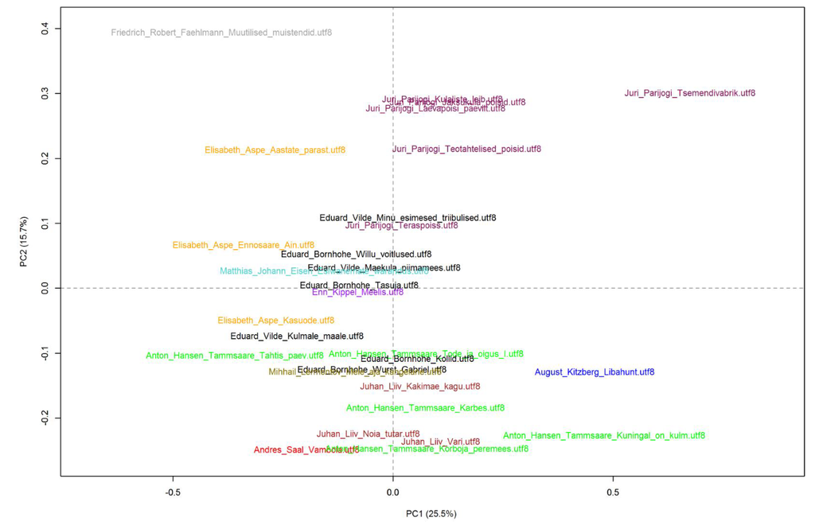

*[Tartu Linnaraamatukogu vabalt kättesaadavate e-raamatute](https://www.luts.ee/index.php/e-raamatud) tekstifailide põhjal tuvastatud sarnasused autorite ja teoste vahel ([Uiboaed 2017](http://www.tekstikaeve.ee/post/kirjandusteoste-automaatanal%C3%BC%C3%BCs/))*

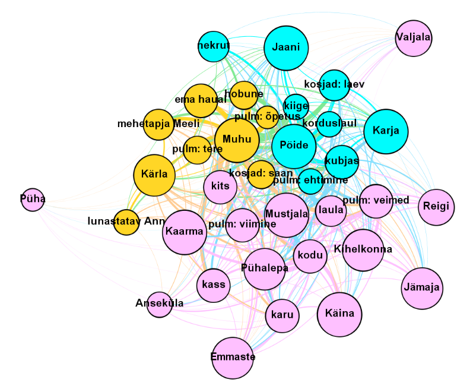

*Hiiumaa, Saaremaa ja Muhu regilauludes esinevate teemade seosed kihelkondadega (Sarv 2020)*

Kõige lihtsam viis mingist tekstist esmast ülevaadet saada on aga kasutada **sõnapilvesid**. Sõnapilve tööpõhimõte on väga lihtne: sagedamini esinevad sõnad on suuremad, harvemini esinevad väiksemad.

Näiteks

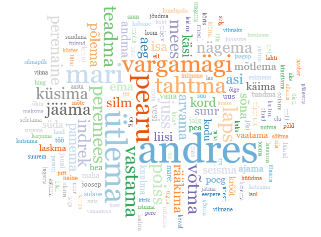

*Sagedasemad sõnad Tammsaare teoses “Tõde ja õigus (1. osa)”*

Vähemalt eesti keele puhul tekib sõnapilve tegemisel aga kaks väga olulist küsimust.

1. **Kuidas määratleda *sõna*?**
   - Kas *olin*, *olid*, *oleksin*, (*ta*) *on*, (*nad*) *on* on erinevad sõnad?
   - Kas *raamatu*, *raamatute*, *raamatuid*, *raamatutetagi* on erinevad sõnad?
2. **Mis on olulised sõnad?**
   - Kas *olema*, *ja*, *see* ütlevad meile midagi teksti sisu kohta?

Sõnapilve tegemisel on niisiis tüüpiliselt kolm tähtsat osa:

- teksti **lemmatiseerimine** ehk sõnavormide viimine nende algkujule (nii, nagu need oleks esitatud sõnaraamatus, nt *olema*, *raamat*),
- nn **stoppsõnade** eemaldamine. Stoppsõnad on keeles kõige sagedamini esinevad sõnad, mis samas teksti analüüsimisel ütlevad selle sisu kohta vähe. Stoppsõnadeks peetakse enamasti näiteks sidesõnu (*ja*, *kui*, *aga*, *sest*), asesõnu (*tema*, *mina*, *see*), mõndasid grammatilisema tähendusega tegusõnu (*olema*, *hakkama*), määrsõnu (*siis*, *nii*, *pärast*), kaassõnu (*taga*, *üle*, *peale*) jm. Samas näiteks erinevate autorite keelekasutust võrreldes võib nende sõnade hulk ja kontekst olla informatiivne.
- **visualiseerimine**.

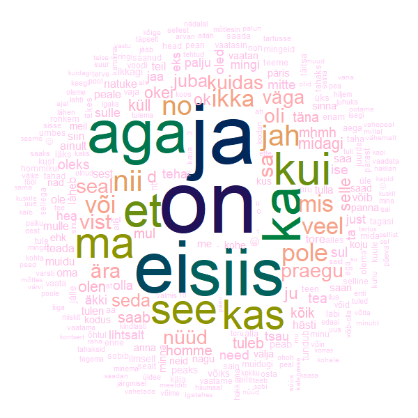

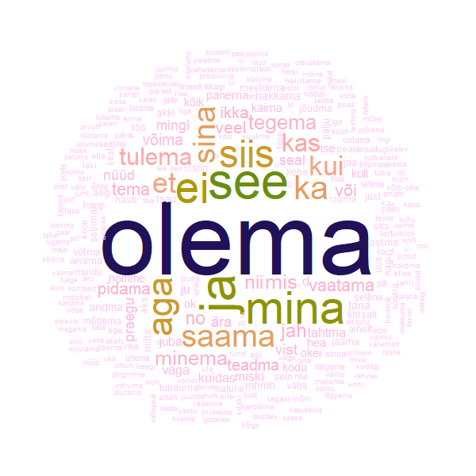

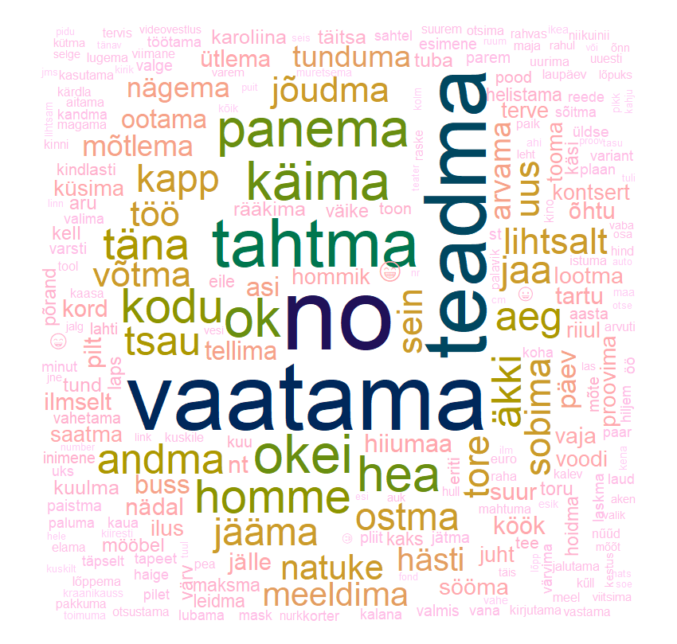

*Sõnapilved sõnavormidest (üleval), lemmatiseeritud sõnadest (keskel) ja lemmatiseeritud sõnadest, kust on eemaldatud stoppsõnad (all)*

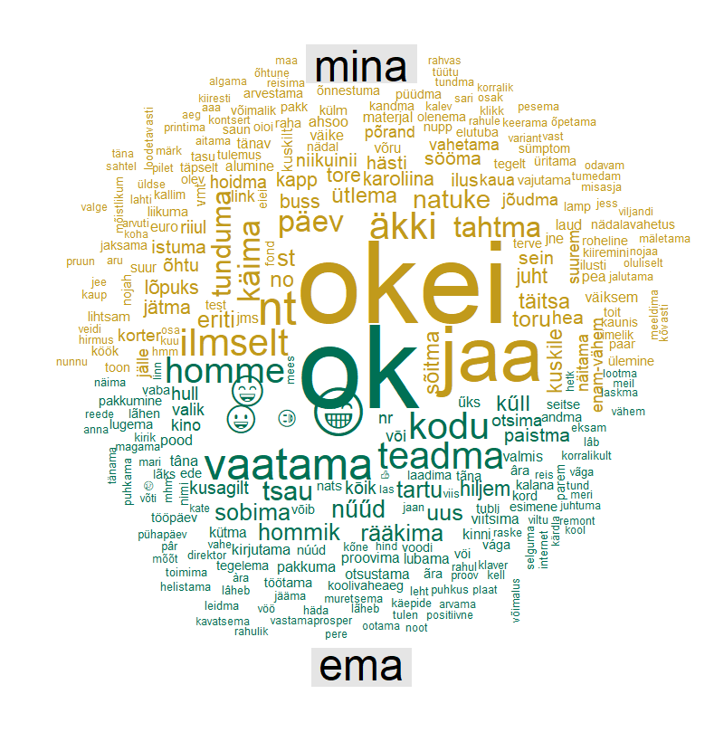

## Tööriistad

- Eestikeelsete tekstide **lemmatiseerimiseks** ehk sõnavormide algkuju leidmiseks saab kasutada näiteks vastavat tööriista lehel https://tekstianalyys.utlib.ut.ee/lemmatiseerimine.html.
  - Ingliskeelsete tekstide lemmatiseerimiseks on veebis mitu tööriista, näiteks võib kasutada seda, mis on lehel http://textanalysisonline.com/spacy-word-lemmatize.
- Eesti keele **stoppsõnade** loendi võib koostada ise või kasutada mõnd olemasolevat, nt lehel [https://datadoi.ee/bitstream/handle/33/78/estonian-stopwords-lemmas.txt](https://datadoi.ee/bitstream/handle/33/78/estonian-stopwords-lemmas.txt?sequence=2&isAllowed=y).
  - Inglise keele stoppsõnade loendeid on ka erinevaid, üks neist näiteks lehel https://www.ranks.nl/stopwords.

# “Eesti laul 2021” laulusõnade analüüs

Selleaastases “Eesti laulu” finaaliseelses saates esitati statistikat selle kohta, kui palju sõnu üks ja teine artist on pidanud oma esituse tarvis ära õppima. Esitatud statistika oli järgmine:

- **Kõige rohkem sõnu**:
  - Suured tüdrukud “Heaven’s not that far tonight” (395)
  - Uku Suviste “The lucky one” (371)
- **Kõige vähem sõnu**:
  - Ivo Linna, Robert Linna & Supernova “Ma olen siin” (95)
- **Kõige rohkem erinevaid sõnu**:
  - Andrei Zevakin & Pluuto “Wingman” (162)
  - Uku Suviste “The lucky one” (134)
  - Suured tüdrukud “Heaven’s not that far tonight” (124)
- **Kõige vähem erinevaid sõnu**:
  - Redel “Tartu” (32)
  - Jüri Pootsmann “Magus melanhoolia” (60)
  - Karl Killing “Kiss me” (60)
- **Kõige populaarsem sõna ingliskeelsetes lauludes**: *I*
  - Egert Milder “Free again” (21)
  - Karl Killing “Kiss me” (16)
  - Koit Toome “We could have been beautiful” (14)
- **Kõige populaarsemad sõnad eestikeelsetes lauludes**: *linn*, *puust*

Vaatame, kuidas nende tulemusteni jõuti, ning kas saame samasugused tulemused! Kasutame “Eesti laulu” [kodulehelt](https://menu.err.ee/k/eesti-laul) “kraabitud” andmestikku, kus on kõikide laulude sõnad (ingliskeelsete laulude puhul ka nende eestikeelsed tõlked). Nagu laulusõnade puhul ikka, on refrääni kordused üldjuhul välja jäetud.

### Ülesanne

Moodustage paarid või suuremad grupid ning valige lehel https://docs.google.com/spreadsheets/d/1LAvYfk5T1JAGLSMtWvhxtPoMJttrnlwEjSq1OP3HYJA/edit?usp=sharing üks laul 11st, mille põhjal allolevaid ülesandeid teha (Redeli “Tartu” teeme näitena koos läbi).

1. Mine lehele https://voyant-tools.org/ ning kleebi valitud laulu tekst kastikesse. Vajuta nuppu *Reveal*.
2. Kui palju sõnu ja *unikaalseid* (st erinevaid) sõnu laulus on? Märgi need arvud tabelisse.
3. Lülita välja automaatne stoppsõnade loend. Selleks liigu Voyant Toolsi *Cirruse*-nimelises sektsioonis (seal, kus on sõnapilv) paremasse ülemisse nurka ning vajuta nupul “Define options for this tool”. Avanenud aknas vali *Stopwords* -> *None*. Seejärel vajuta *Save* ning *Confirm*. Mis on laulu kõige sagedasem sõna? Kirjuta see tabelisse.
4. Lemmatiseeri tekst.
   - Kui sinu valitud laulu originaaltekst on **eesti keeles**, mine lehele https://tekstianalyys.utlib.ut.ee/lemmatiseerimine.html, kopeeri laulu tekst kastikesse, vajuta nupul *Analüüsi* ning kopeeri uuesti väljundiks antud lemmatiseeritud tekst.
   - Kui sinu valitud laulu originaaltekst on **inglise keeles**, mine lehele http://textanalysisonline.com/spacy-word-lemmatize, kopeeri laulu tekst kastikesse, vajuta nupul *spaCy Word Lemmatize* ning kopeeri uuesti väljundiks antud lemmatiseeritud tekst.
5. Ava uuel vahelehel uus [Voyant Toolsi](https://voyant-tools.org/) aken. Kleebi nüüd lemmatiseeritud tekst tühja Voyant Toolsi kasti ja vajuta jälle nuppu *Reveal*.
6. Lülita uuesti välja automaatne stoppsõnade loend. Märgi tabelisse lemmatiseeritud sõnade arv, unikaalsete lemmatiseeritud sõnade arv ja kõige sagedasem lemmatiseeritud sõna. Võrdle tulemusi. Mida märkad?
7. Märgi tabelisse, kui sage on lemmatiseeritud laulutekstis sõna *I* (ingl k) või *mina/ma*.
8. Jäta lemmatiseeritud tekstist välja stoppsõnad.
   - Eestikeelsed stoppsõnad leiad tabeli vahelehelt *stoppsõnad_eesti*.
   - Ingliskeelsed stoppsõnad leiad tabeli vahelehelt *stoppsõnad_inglise*.
   - Kopeeri vastava keele stoppsõnad, liigu Voyant Toolsi *Cirruse*-nimelises sektsioonis (seal, kus on sõnapilv) paremasse ülemisse nurka ning vajuta nupul “Define options for this tool”. Avanenud aknas vali *Stopwords* -> *New User-Defined List* -> *Edit List*, kustuta omakorda avanenud aknakeses sõna *new* ning kleebi kõik stoppsõnad kastikesse. Seejärel vajuta *Save* ning *Confirm*.
9. Mis on nüüd kõige populaarsem sõna?
10. Uuri veel lemmatiseeritud ja lemmatiseerimata tekste ning tööriista võimalusi. Mida märkad?

# Keelevarieerumine

Kuidas me valime “võrdsete” väljendite vahel?

Ja siis **ma olen** nagu sangar seiklusfilmis,  
ohu ees **ei sule** iial silmi.  
**Ei ma satu** hätta  
ja ükski neiu jätta  
mind ei enam saa.  
Kui tarvis, tähti taevast alla tooma **sõidan**,  
igas paigas aina kuulsust **võidan**.  
Kasvõi tiigrit **paitan**,  
jah, miski siin ei aita,  
kõigist julgem **ma**,  
kõigist julgem **olen ma**.

Paljudes keeltes on asesõnade kasutamine kohustuslik. Näiteks inglise keeles oleks lause *Ate an apple ebagrammatiline. Eesti keeles aga on *Sõin õuna* täiesti vastuvõetav ja justkui samatähenduslik lausetega *Ma sõin õuna* või *Mina sõin õuna*. Mingis mõttes teeme asesõna kasutamisega nagu topelttööd, sest sama infot (“tegijaks olin mina”) väljendab ju ka tegusõna pöördelõpp.  
Ometi on mingid kontekstid, kus oleme harjunud kasutama asesõnaga väljendeid rohkem kui ilma asesõnata ja kui sellistes kontekstides asendada harjumuspärane alternatiivse variandiga, tundub see võõras. Niisamuti ka vastupidi.

### Ülesanne

- missugustes kontekstides tundub asesõna *mina/ma* väljajätmine loomulikum;
- missugustes kontekstides tundub asesõna *mina/ma* kasutamine loomulikum;
- mis võiks veel asesõna kasutamist mõjutada.